# EDA for OZNAL project

Filip Remšík, Filip Mojto

2025-05-02

# 01 - EDA

In this document we perform Exploratory Data Analysis. The input is the hypothesis, target and potential predictors. The output is a list of predictors that best fit for model training, plus recommended models and actions for data preprocessing.

Our hypothesis is as follows:

*“Vehicle prices can be reliably predicted using a combination of manufacturer (brand), vehicle specifications (age, mileage, engine type), and geographic (location) features, with brand and age being the most significant predictors.”*

## Libraries

This is a list of libraries we are going to need throughout this document. Must be run before any other block.

```r
library(tidyverse)
```

```r
library(conflicted)
library(corrplot)
library(purrr)
library(caret)
library(nnet)
library(pROC)
library(scales)  # for comma()

conflict_prefer("filter", "dplyr")
```

```
## [conflicted] Will prefer dplyr::filter over any other package.
```

```r
conflict_prefer("lag", "dplyr")
```

```
## [conflicted] Will prefer dplyr::lag over any other package.
```

```r
conflict_prefer("select", "dplyr")
```

```
## [conflicted] Will prefer dplyr::select over any other package.
```

## Dataset

Now we can load the vehicle dataset. It contains over 15 000 observations and also various car-related attributes like Brand, Model, Year, etc. The dataset should be stored in /data/raw as csv. Having loaded the dataset correctly we can check its basic summary.

```r
paste("Loading dataset from '", getwd(), "'")
```

```
## [1] "Loading dataset from ' C:/Users/fmojt/Documents/DataAnalysisProjects/OZNAL-project/documentation/cars '"
```

```r
df <- read_csv("../../data/raw/australian_vehicle_prices.csv", show_col_types = FALSE)
summary(df)
```

```
##     Brand                Year         Model             Car/Suv
##  Length:16734       Min.   :1940   Length:16734       Length:16734
##  Class :character   1st Qu.:2013   Class :character   Class :character
##  Mode  :character   Median :2017   Mode  :character   Mode  :character
##                     Mean   :2016
##                     3rd Qu.:2020
##                     Max.   :2023
##                     NA's   :1
##     Title            UsedOrNew         Transmission          Engine
##  Length:16734       Length:16734       Length:16734       Length:16734
##  Class :character   Class :character   Class :character   Class :character
##  Mode  :character   Mode  :character   Mode  :character   Mode  :character
##
##
##
##
##   DriveType           FuelType         FuelConsumption     Kilometres
##  Length:16734       Length:16734       Length:16734       Length:16734
##  Class :character   Class :character   Class :character   Class :character
##  Mode  :character   Mode  :character   Mode  :character   Mode  :character
##
##
##
##
##  ColourExtInt         Location         CylindersinEngine    BodyType
##  Length:16734       Length:16734       Length:16734       Length:16734
##  Class :character   Class :character   Class :character   Class :character
##  Mode  :character   Mode  :character   Mode  :character   Mode  :character
##
##
##
##
##     Doors              Seats               Price
##  Length:16734       Length:16734       Min.   :     88
##  Class :character   Class :character   1st Qu.:  18999
##  Mode  :character   Mode  :character   Median :  29500
##                                        Mean   :  37303
##                                        3rd Qu.:  43990
##                                        Max.   :1500000
##                                        NA's   :53
```

From the summary above we can see a lot of predictors are not numerical. A large portion of such columns are categorical. For instance:

1. *Brand*
2. *Model*
3. *Car/Suv*

…

These parameters will need to be converted into numbers using some kind of encoding as we think they can have high influence on the price.

Some attributes like *Title* are redundant as they bring no new information and would only complicate our model. Thus, these attributes won’t be included.

## Target & Predictors

After viewing the summary in previous section we have chosen the following predictors:

```r
colnames(df)[colnames(df) == "Car/Suv"] <- "Car_Suv"

PREDICTORS <- c('Brand_encoded', 'age', 'Model_encoded',
                'Car_Suv_encoded', 'UsedOrNew_encoded',
                'Transmission_encoded', 'Kilometres_num',
                'Cylinders', 'Engine_L', 'DriveType_encoded',
                'FuelType_encoded', 'FuelConsumption_num',
                'ColourExtInt_encoded', 'Location_encoded',
                'BodyType_encoded', 'Doors_num', 'Seats_num')
TARGET <- 'Price'
df
```

```
## # A tibble: 16,734 × 19
##    Brand        Year Model Car_Suv Title UsedOrNew Transmission Engine DriveType
##    <chr>       <dbl> <chr> <chr>   <chr> <chr>     <chr>        <chr>  <chr>
##  1 Ssangyong    2022 Rext… Suther… 2022… DEMO      Automatic    4 cyl… AWD
##  2 MG           2022 MG3   Hatchb… 2022… USED      Automatic    4 cyl… Front
##  3 BMW          2022 430I  Coupe   2022… USED      Automatic    4 cyl… Rear
##  4 Mercedes-B…  2011 E500  Coupe   2011… USED      Automatic    8 cyl… Rear
##  5 Renault      2022 Arka… SUV     2022… USED      Automatic    4 cyl… Front
##  6 Toyota       2004 Esti… ON FOU… 2004… USED      Automatic    -      Other
##  7 Land         2017 Rover SUV     2017… USED      Automatic    4 cyl… AWD
##  8 Nissan       2000 Puls… Hatchb… 2000… USED      Automatic    4 cyl… Front
##  9 Toyota       2013 86    Coupe   2013… USED      Automatic    4 cyl… Rear
## 10 Honda        2014 Jazz  Hatchb… 2014… USED      Automatic    4 cyl… Front
## # ℹ 16,724 more rows
## # ℹ 10 more variables: FuelType <chr>, FuelConsumption <chr>, Kilometres <chr>,
## #   ColourExtInt <chr>, Location <chr>, CylindersinEngine <chr>,
## #   BodyType <chr>, Doors <chr>, Seats <chr>, Price <dbl>
```

## Preprocessing

We already identified some anomalies in the data that need to be dealt with before diving into EDA. First it is the missing values.

### Missing Values

First we calculate the portion of missing values for each attribute.

```r
# For a single column (e.g., 'Seats')
colMeans(is.na(df))
```

```
##             Brand              Year             Model           Car_Suv
##      5.975858e-05      5.975858e-05      5.975858e-05      0.000000e+00
##             Title         UsedOrNew      Transmission            Engine
##      5.975858e-05      0.000000e+00      5.975858e-05      5.975858e-05
##         DriveType          FuelType   FuelConsumption        Kilometres
##      5.975858e-05      5.975858e-05      5.975858e-05      5.975858e-05
##      ColourExtInt          Location CylindersinEngine          BodyType
##      5.975858e-05      2.689136e-02      0.000000e+00      1.685192e-02
##             Doors             Seats             Price
##      9.585275e-02      1.018884e-01      3.167204e-03
```

From the values we can tell that the portion ranges from 0% to 10%. We can declare that this dataset doesn’t contain significant amount of missing values except for attribute *Seats*. We will recommend appropriate actions later in this document but now, for the purpose of EDA, we simply remove all rows that contain any missing values.

```r
df <- df %>%
  filter(complete.cases(.))
```

### Encoding

Because data contain a lot of categorical attributes that are relevant to our goal, we’ve created the following function. This function performs so-called **Target Encoding** which is different from standard one-hot encoding in that that is encodes the categories based on how strong impact the predictor has on the target. Higher average price for the particular predictors means higher assigned number.

```r
target.encode <- function(df, target, col) {
  # Convert column name to symbol for tidy evaluation
  col_sym <- sym(col)
  encoded_col_name <- paste0(col, "_encoded")

  # Step 1: Calculate mean target per group
  avg_target <- df %>%
    group_by(!!col_sym) %>%
    summarise(mean_target = mean(.data[[target]], na.rm = TRUE), .groups = "drop") %>%
    arrange(mean_target)

  # Step 2: Assign ranks
  avg_target <- avg_target %>%
    mutate(!!encoded_col_name := as.numeric(factor(mean_target, levels = unique(mean_target))) - 1)

  # Step 3: Join encoded column back to original dataframe
  df <- df %>%
    left_join(avg_target %>% select(!!col_sym, !!sym(encoded_col_name)), by = col)

  return(df)
}
```

### Target Encoding

These are columns that need to be encoded. We simply apply the function defined above on each of them.

```r
COLS_TO_ENCODE <- c('Brand', 'Model', 'Car_Suv', 'UsedOrNew', 'Transmission', 'DriveType', 'FuelType', 'ColourExtInt', 'Location', 'BodyType')


df <- reduce(COLS_TO_ENCODE, ~ target.encode(df = .x, target = TARGET, col = .y), .init = df)

df
```

```
## # A tibble: 14,551 × 29
##    Brand        Year Model Car_Suv Title UsedOrNew Transmission Engine DriveType
##    <chr>       <dbl> <chr> <chr>   <chr> <chr>     <chr>        <chr>  <chr>
##  1 Ssangyong    2022 Rext… Suther… 2022… DEMO      Automatic    4 cyl… AWD
##  2 MG           2022 MG3   Hatchb… 2022… USED      Automatic    4 cyl… Front
##  3 BMW          2022 430I  Coupe   2022… USED      Automatic    4 cyl… Rear
##  4 Mercedes-B…  2011 E500  Coupe   2011… USED      Automatic    8 cyl… Rear
##  5 Renault      2022 Arka… SUV     2022… USED      Automatic    4 cyl… Front
##  6 Land         2017 Rover SUV     2017… USED      Automatic    4 cyl… AWD
##  7 Nissan       2000 Puls… Hatchb… 2000… USED      Automatic    4 cyl… Front
##  8 Toyota       2013 86    Coupe   2013… USED      Automatic    4 cyl… Rear
##  9 Honda        2014 Jazz  Hatchb… 2014… USED      Automatic    4 cyl… Front
## 10 Toyota       2018 HiAce Commer… 2018… USED      Automatic    4 cyl… Rear
## # ℹ 14,541 more rows
## # ℹ 20 more variables: FuelType <chr>, FuelConsumption <chr>, Kilometres <chr>,
## #   ColourExtInt <chr>, Location <chr>, CylindersinEngine <chr>,
## #   BodyType <chr>, Doors <chr>, Seats <chr>, Price <dbl>, Brand_encoded <dbl>,
## #   Model_encoded <dbl>, Car_Suv_encoded <dbl>, UsedOrNew_encoded <dbl>,
## #   Transmission_encoded <dbl>, DriveType_encoded <dbl>,
## #   FuelType_encoded <dbl>, ColourExtInt_encoded <dbl>, …
```

### Year -> Age

Age is time-based feature and thus it introduces inflation. Is is therefore wise to convert it into age using the following formula:

*age = current - manufacturing_year*

```r
current_year <- as.numeric(format(Sys.Date(), "%Y"))
df$age <- current_year - df$Year
```

### Engine -> Cylinders, Engine

```r
# extract actually replaces the original column with new ones based on regex match
df <- df %>%
  extract(
    Engine,                 # The source column containing engine info
    into = c("Cylinders", "Engine_L"),  # New columns to create
    regex = "(\\d+) cyl, (\\d+\\.?\\d*) L",  # Pattern to match
    convert = TRUE          # Automatically convert to appropriate data types
  )

df
```

```
## # A tibble: 14,551 × 31
##    Brand      Year Model Car_Suv Title UsedOrNew Transmission Cylinders Engine_L
##    <chr>     <dbl> <chr> <chr>   <chr> <chr>     <chr>            <int>    <dbl>
##  1 Ssangyong  2022 Rext… Suther… 2022… DEMO      Automatic            4      2.2
##  2 MG         2022 MG3   Hatchb… 2022… USED      Automatic            4      1.5
##  3 BMW        2022 430I  Coupe   2022… USED      Automatic            4      2
##  4 Mercedes…  2011 E500  Coupe   2011… USED      Automatic            8      5.5
##  5 Renault    2022 Arka… SUV     2022… USED      Automatic            4      1.3
##  6 Land       2017 Rover SUV     2017… USED      Automatic            4      2
##  7 Nissan     2000 Puls… Hatchb… 2000… USED      Automatic            4      1.6
##  8 Toyota     2013 86    Coupe   2013… USED      Automatic            4      2
##  9 Honda      2014 Jazz  Hatchb… 2014… USED      Automatic            4      1.3
## 10 Toyota     2018 HiAce Commer… 2018… USED      Automatic            4      2.7
## # ℹ 14,541 more rows
## # ℹ 22 more variables: DriveType <chr>, FuelType <chr>, FuelConsumption <chr>,
## #   Kilometres <chr>, ColourExtInt <chr>, Location <chr>,
## #   CylindersinEngine <chr>, BodyType <chr>, Doors <chr>, Seats <chr>,
## #   Price <dbl>, Brand_encoded <dbl>, Model_encoded <dbl>,
## #   Car_Suv_encoded <dbl>, UsedOrNew_encoded <dbl>, Transmission_encoded <dbl>,
## #   DriveType_encoded <dbl>, FuelType_encoded <dbl>, …
```

### FuelComsumption

```r
df <- df %>%
  mutate(
    FuelConsumption_num = as.numeric(str_extract(FuelConsumption, "\\d+\\.?\\d*"))
  )

df
```

```
## # A tibble: 14,551 × 32
##    Brand      Year Model Car_Suv Title UsedOrNew Transmission Cylinders Engine_L
##    <chr>     <dbl> <chr> <chr>   <chr> <chr>     <chr>            <int>    <dbl>
##  1 Ssangyong  2022 Rext… Suther… 2022… DEMO      Automatic            4      2.2
##  2 MG         2022 MG3   Hatchb… 2022… USED      Automatic            4      1.5
##  3 BMW        2022 430I  Coupe   2022… USED      Automatic            4      2
##  4 Mercedes…  2011 E500  Coupe   2011… USED      Automatic            8      5.5
##  5 Renault    2022 Arka… SUV     2022… USED      Automatic            4      1.3
##  6 Land       2017 Rover SUV     2017… USED      Automatic            4      2
##  7 Nissan     2000 Puls… Hatchb… 2000… USED      Automatic            4      1.6
##  8 Toyota     2013 86    Coupe   2013… USED      Automatic            4      2
##  9 Honda      2014 Jazz  Hatchb… 2014… USED      Automatic            4      1.3
## 10 Toyota     2018 HiAce Commer… 2018… USED      Automatic            4      2.7
## # ℹ 14,541 more rows
## # ℹ 23 more variables: DriveType <chr>, FuelType <chr>, FuelConsumption <chr>,
## #   Kilometres <chr>, ColourExtInt <chr>, Location <chr>,
## #   CylindersinEngine <chr>, BodyType <chr>, Doors <chr>, Seats <chr>,
## #   Price <dbl>, Brand_encoded <dbl>, Model_encoded <dbl>,
## #   Car_Suv_encoded <dbl>, UsedOrNew_encoded <dbl>, Transmission_encoded <dbl>,
## #   DriveType_encoded <dbl>, FuelType_encoded <dbl>, …
```

### Doors and Seats

```r
df$Doors_num <- as.numeric(gsub("[^0-9]", "", df$Doors))
df$Seats_num <- as.numeric(gsub("[^0-9]", "", df$Seats))
```

After preprocessing is over, we can visualize the final dataset.

```r
df
```

```
## # A tibble: 14,551 × 34
##    Brand      Year Model Car_Suv Title UsedOrNew Transmission Cylinders Engine_L
##    <chr>     <dbl> <chr> <chr>   <chr> <chr>     <chr>            <int>    <dbl>
##  1 Ssangyong  2022 Rext… Suther… 2022… DEMO      Automatic            4      2.2
##  2 MG         2022 MG3   Hatchb… 2022… USED      Automatic            4      1.5
##  3 BMW        2022 430I  Coupe   2022… USED      Automatic            4      2
##  4 Mercedes…  2011 E500  Coupe   2011… USED      Automatic            8      5.5
##  5 Renault    2022 Arka… SUV     2022… USED      Automatic            4      1.3
##  6 Land       2017 Rover SUV     2017… USED      Automatic            4      2
##  7 Nissan     2000 Puls… Hatchb… 2000… USED      Automatic            4      1.6
##  8 Toyota     2013 86    Coupe   2013… USED      Automatic            4      2
##  9 Honda      2014 Jazz  Hatchb… 2014… USED      Automatic            4      1.3
## 10 Toyota     2018 HiAce Commer… 2018… USED      Automatic            4      2.7
## # ℹ 14,541 more rows
## # ℹ 25 more variables: DriveType <chr>, FuelType <chr>, FuelConsumption <chr>,
## #   Kilometres <chr>, ColourExtInt <chr>, Location <chr>,
## #   CylindersinEngine <chr>, BodyType <chr>, Doors <chr>, Seats <chr>,
## #   Price <dbl>, Brand_encoded <dbl>, Model_encoded <dbl>,
## #   Car_Suv_encoded <dbl>, UsedOrNew_encoded <dbl>, Transmission_encoded <dbl>,
## #   DriveType_encoded <dbl>, FuelType_encoded <dbl>, …
```

```r
unique(df$UsedOrNew)
```

```
## [1] "DEMO" "USED" "NEW"
```

```r
summary(df)
```

```
##     Brand                Year         Model             Car_Suv
##  Length:14551       Min.   :1978   Length:14551       Length:14551
##  Class :character   1st Qu.:2013   Class :character   Class :character
##  Mode  :character   Median :2017   Mode  :character   Mode  :character
##                     Mean   :2016
##                     3rd Qu.:2020
##                     Max.   :2023
##
##     Title            UsedOrNew         Transmission         Cylinders
##  Length:14551       Length:14551       Length:14551       Min.   : 2.000
##  Class :character   Class :character   Class :character   1st Qu.: 4.000
##  Mode  :character   Mode  :character   Mode  :character   Median : 4.000
##                                                           Mean   : 4.449
##                                                           3rd Qu.: 4.000
##                                                           Max.   :12.000
##                                                           NA's   :91
##     Engine_L      DriveType           FuelType         FuelConsumption
##  Min.   :0.700   Length:14551       Length:14551       Length:14551
##  1st Qu.:2.000   Class :character   Class :character   Class :character
##  Median :2.200   Mode  :character   Mode  :character   Mode  :character
##  Mean   :2.407
##  3rd Qu.:2.800
##  Max.   :7.300
##  NA's   :91
##   Kilometres        ColourExtInt         Location         CylindersinEngine
##  Length:14551       Length:14551       Length:14551       Length:14551
##  Class :character   Class :character   Class :character   Class :character
##  Mode  :character   Mode  :character   Mode  :character   Mode  :character
##
##
##
##
##    BodyType            Doors              Seats               Price
##  Length:14551       Length:14551       Length:14551       Min.   :    88
##  Class :character   Class :character   Class :character   1st Qu.: 18990
##  Mode  :character   Mode  :character   Mode  :character   Median : 28990
##                                                           Mean   : 34980
##                                                           3rd Qu.: 42755
##                                                           Max.   :649880
##
```

[output cut: 17 more lines]

```
##  Min.   :  0.0    Min.   :0.000    Min.   : 2.000   Min.   : 0.000
##  1st Qu.:192.0    1st Qu.:3.000    1st Qu.: 5.000   1st Qu.: 6.600
##  Median :326.0    Median :4.000    Median : 8.000   Median : 7.600
##  Mean   :313.1    Mean   :3.601    Mean   : 8.776   Mean   : 7.736
##  3rd Qu.:429.0    3rd Qu.:5.000    3rd Qu.:12.000   3rd Qu.: 8.800
##  Max.   :581.0    Max.   :9.000    Max.   :47.000   Max.   :27.000
##
##    Doors_num       Seats_num
##  Min.   :2.000   Min.   : 2.000
##  1st Qu.:4.000   1st Qu.: 5.000
##  Median :4.000   Median : 5.000
##  Mean   :4.023   Mean   : 5.122
##  3rd Qu.:4.000   3rd Qu.: 5.000
##  Max.   :5.000   Max.   :22.000
##
```

## EDA

### Linearity

In this section we check how well do the predictors correlate with the target. We will utilize Scatterplots for that. We also try to draw a linear line in the plot to see if there is linear relationship.

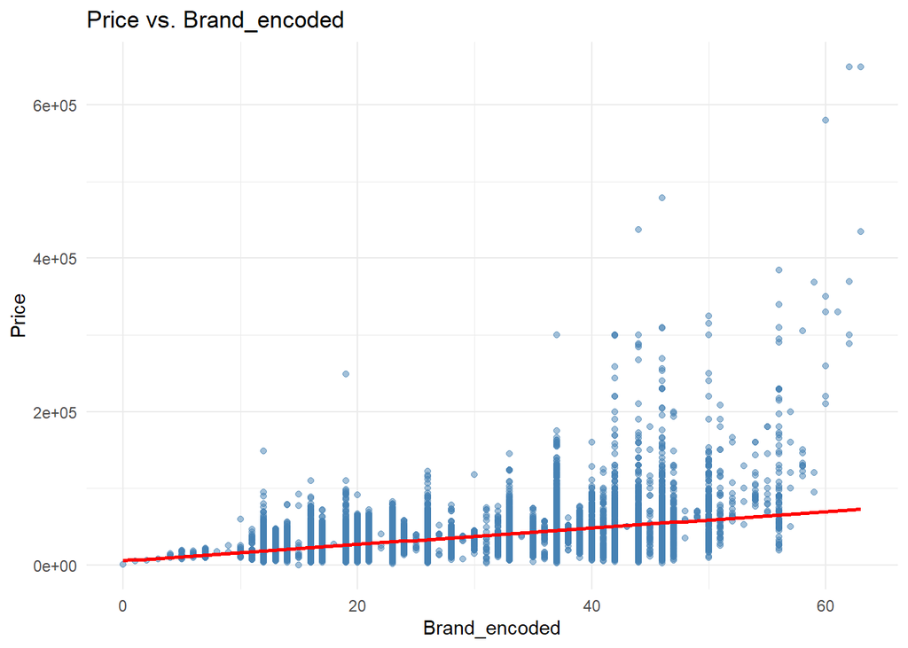

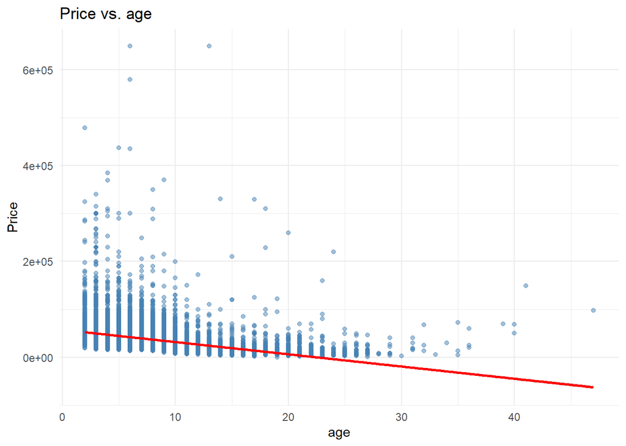

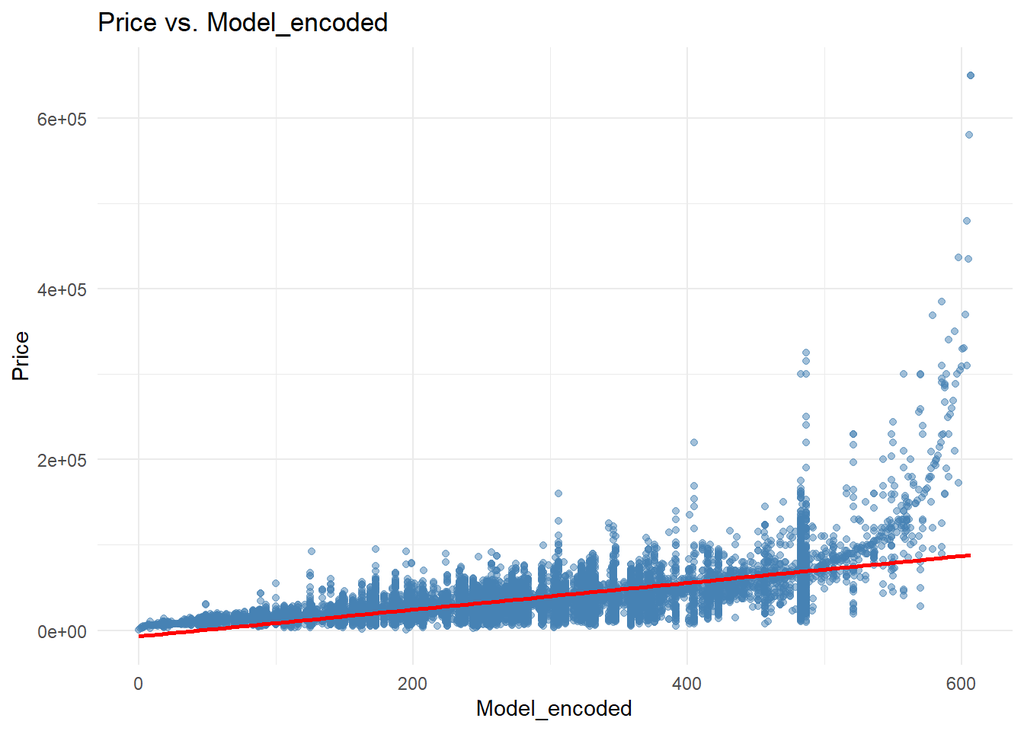

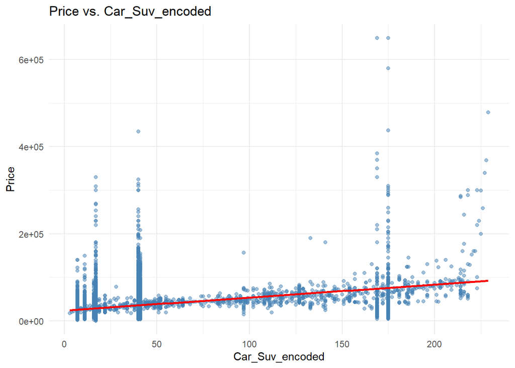

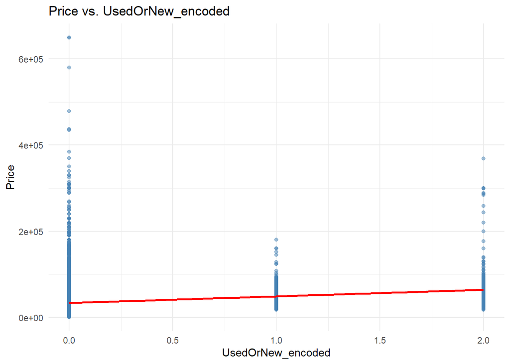

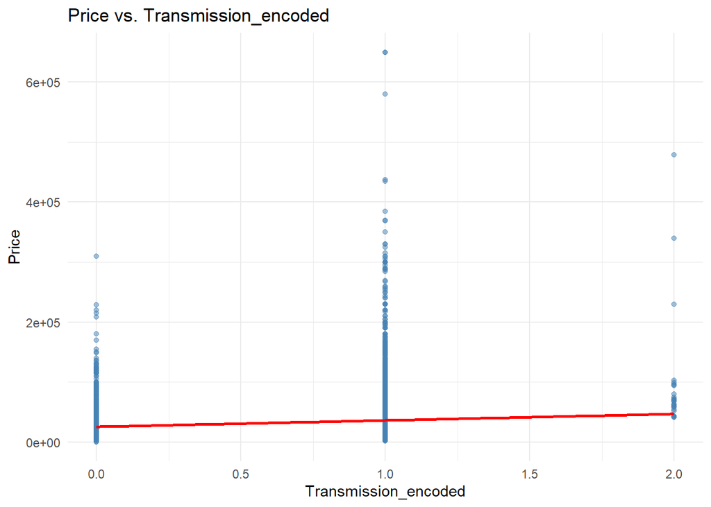

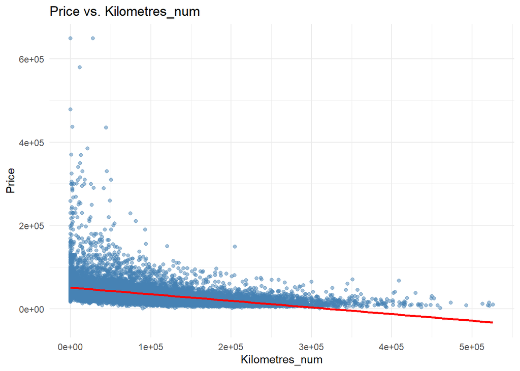

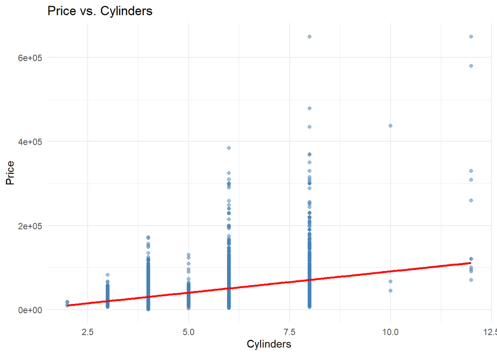

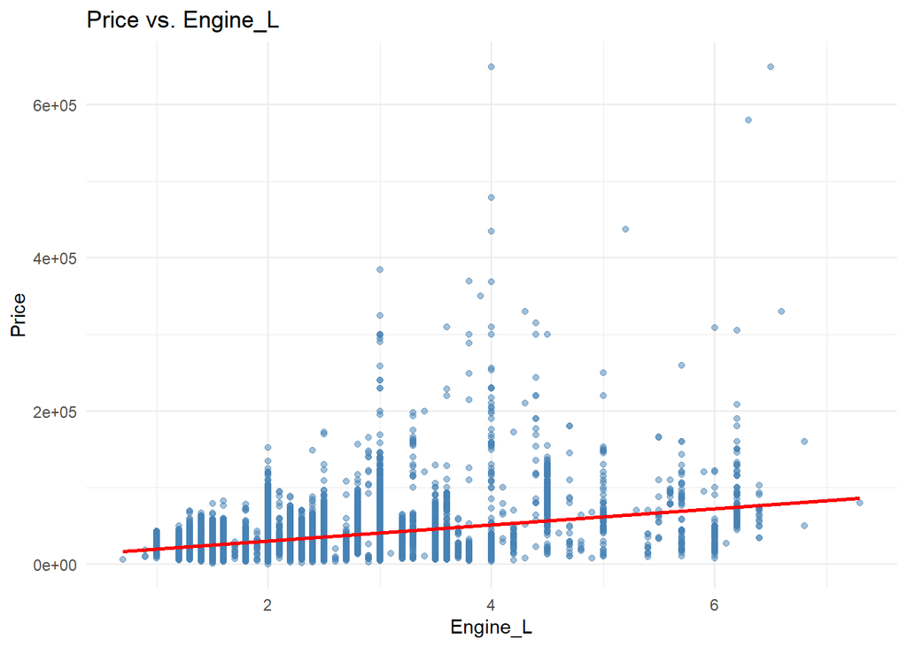

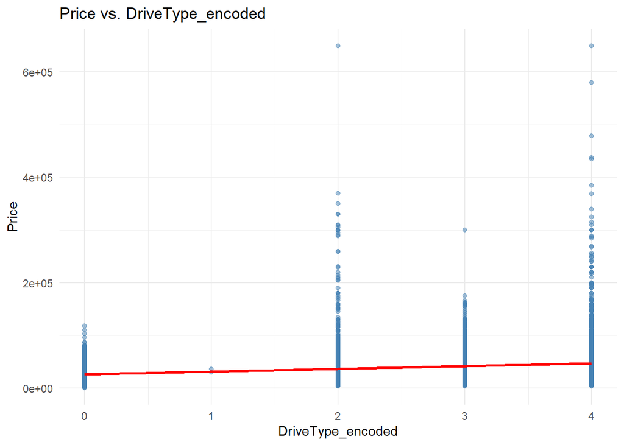

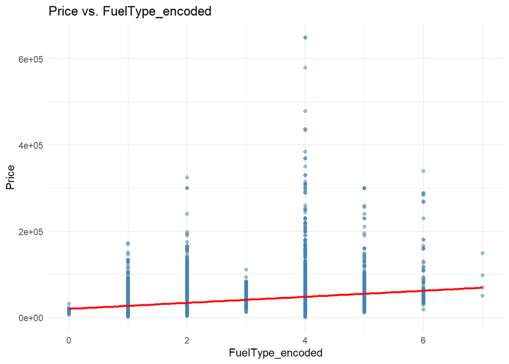

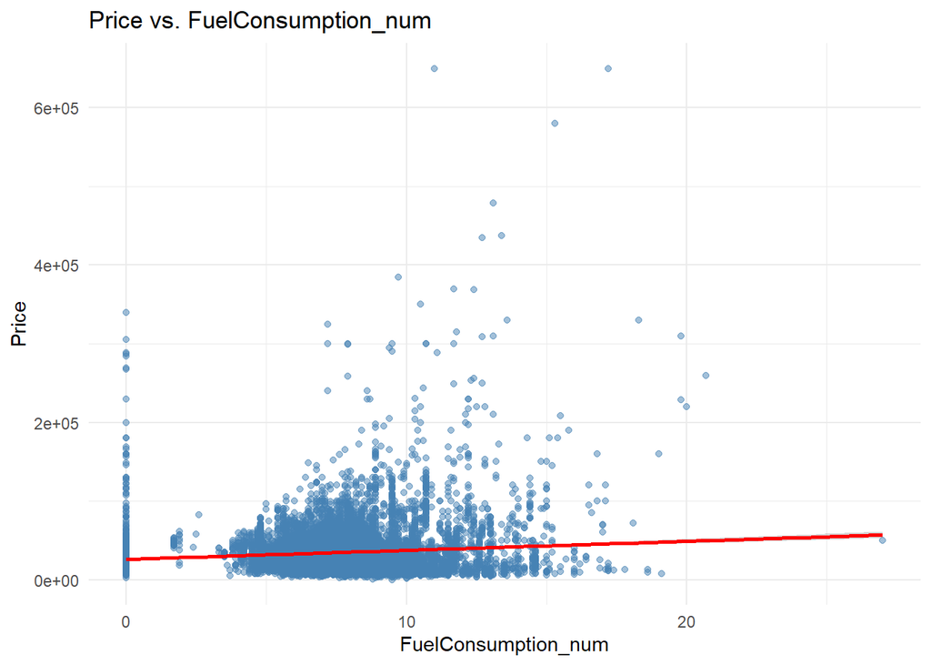

[5 more figures not shown]

```r
df <- df %>%
  mutate(Kilometres_num = as.numeric(gsub("[^0-9]", "", Kilometres)))

df <- df %>%
  filter(!is.na(Kilometres_num), !is.na(Price))


show.correlation.plot <- function(df, target, col){

  p <- ggplot(df, aes(x = .data[[col]], y = .data[[target]])) +
    geom_point(alpha = 0.5, color = "steelblue") +
    geom_smooth(method = "lm", color = "red") +  # Linear trend line
    labs(title = paste0(target, " vs. ", col), x = col, y = target) +
    theme_minimal()

  return(p)
}

plots <- map(PREDICTORS, ~show.correlation.plot(df = df, target = TARGET, col = .x))
walk(plots, print)
```

### Colinearity

We also need to check whether there are not high correlations between individual predictors. This kind of predictors is duplicate and bring no new information to the model function.

In order to show the multicollinearity in a nice way, we are going to use and display a Correlation Matrix. If the values are above a significant level (0.7 in our case) there is a serious collinearity between predictors.

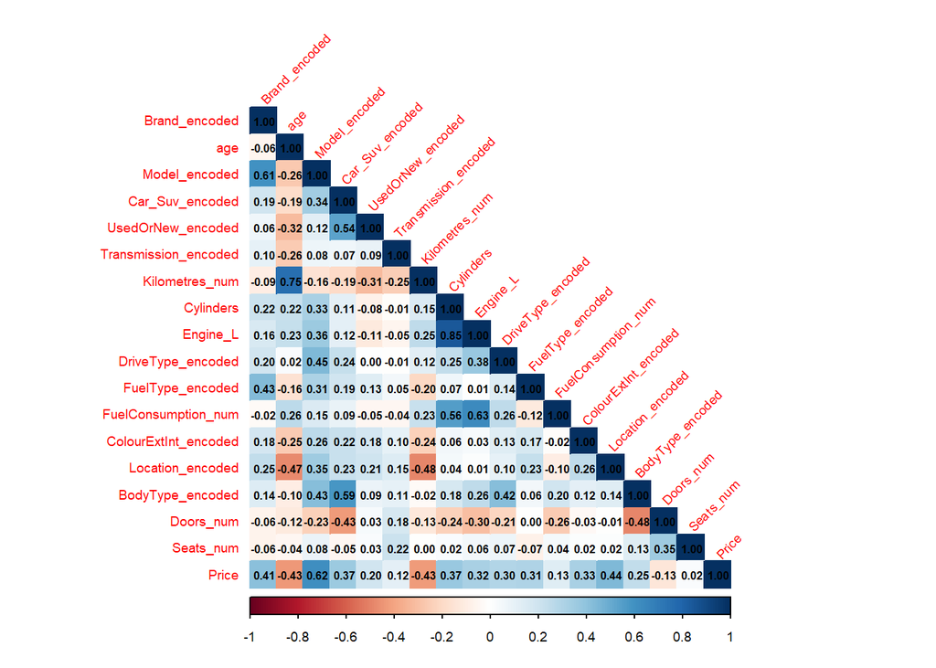

[output not shown]

[output cut: 238 more lines]

[output not shown]

```r
show.corrplot <- function(matrix){
  p <- corrplot(
    matrix,
    method = 'color',
    type = 'lower',
    tl.cex = 0.6,        # much smaller axis text
    cl.cex = 0.6,        # smaller colorbar text
    addCoef.col = "black",
    number.cex = 0.5,    # smaller correlation coefficients
    tl.srt = 45
  )

  print(p)
}


cor_data <- df %>% select(all_of(PREDICTORS), all_of(TARGET))
cor_matrix <- cor(cor_data, use = "complete.obs")
show.corrplot(cor_matrix)
```

From the matrix we can see, that several pairs like:

1. *Kilometres_num* and *age* (0.75)
2. *Model_encoded* and *Brand_encoded* *(0.61)*
3. *UsedOrNew_encoded* and *Car_Suv_encoded* *(0.54)*

have quite high correlation.

### Outliers

We also need to visualize the proportion of outliers present in our data. To achieve this in a neat and representative way, we are going to utilize Boxplots.

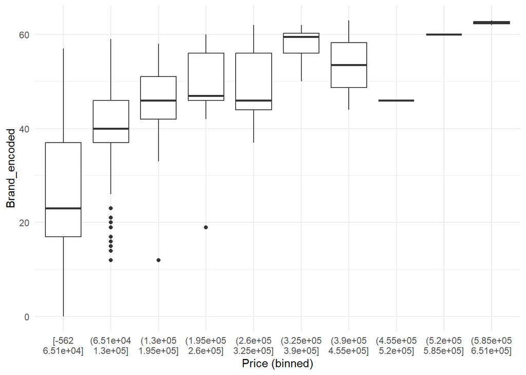

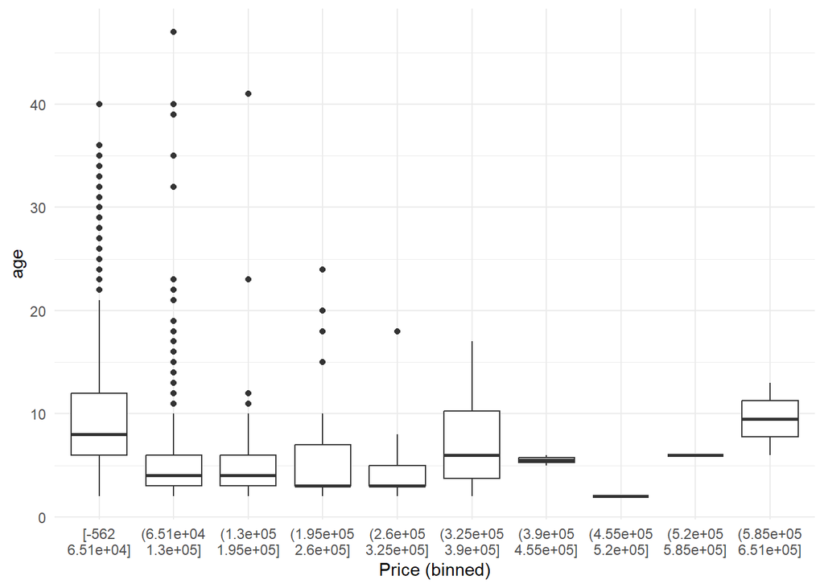

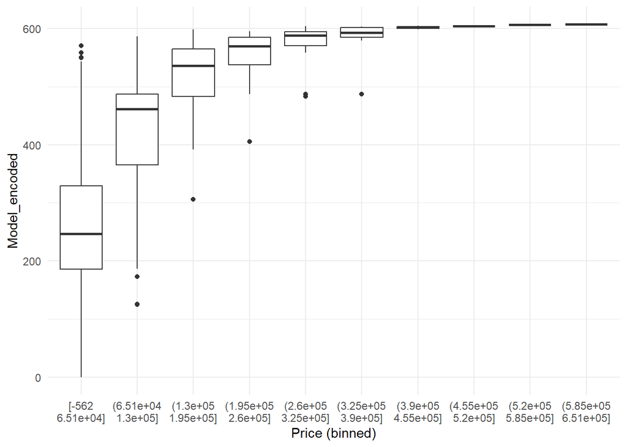

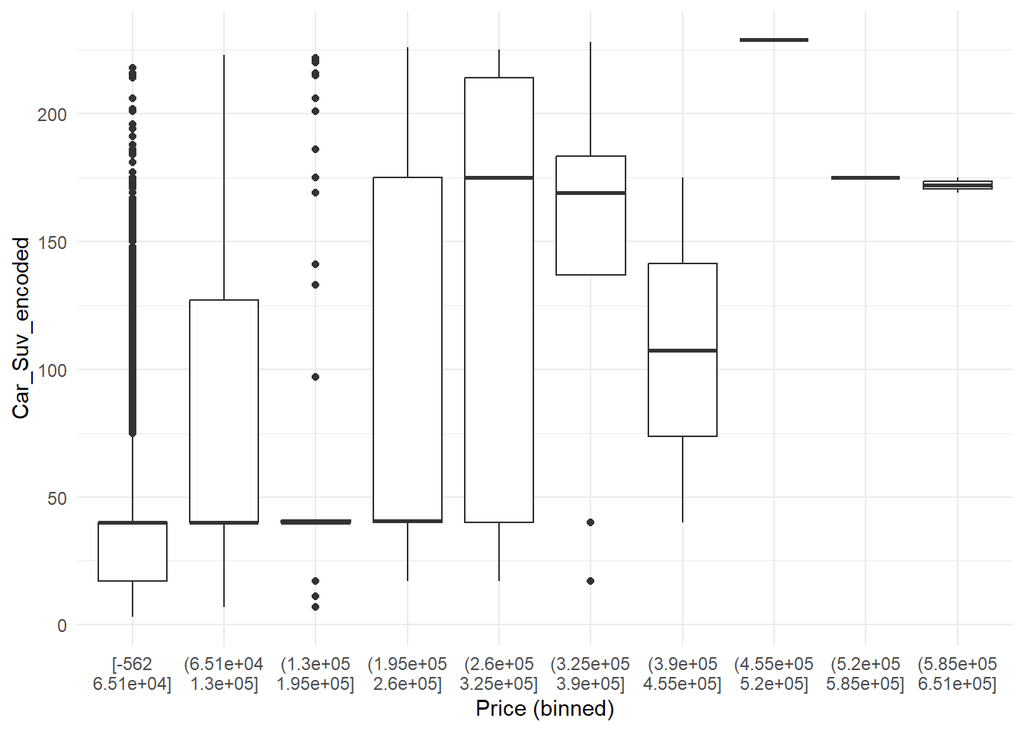

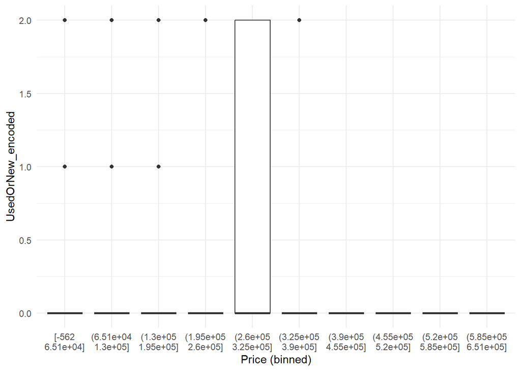

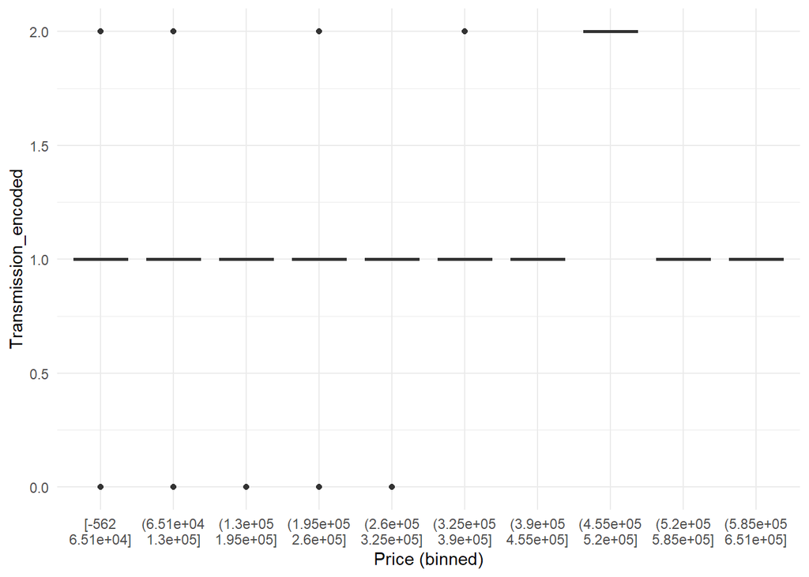

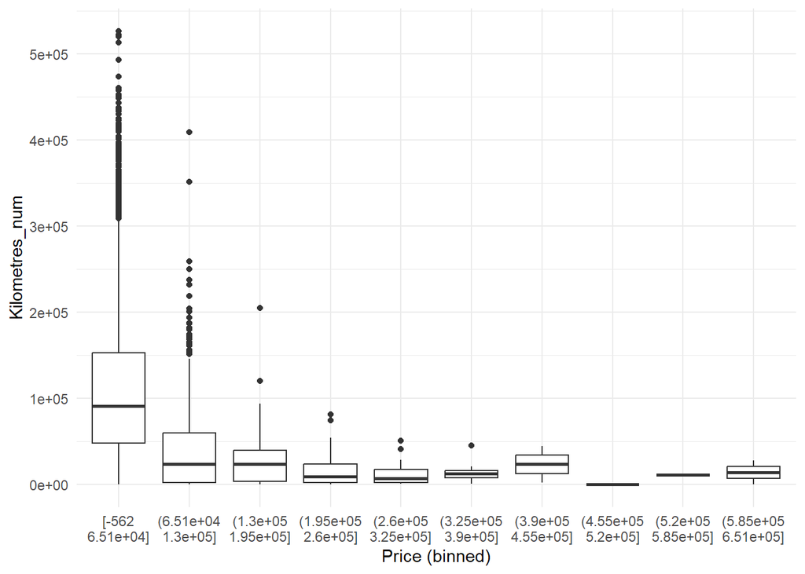

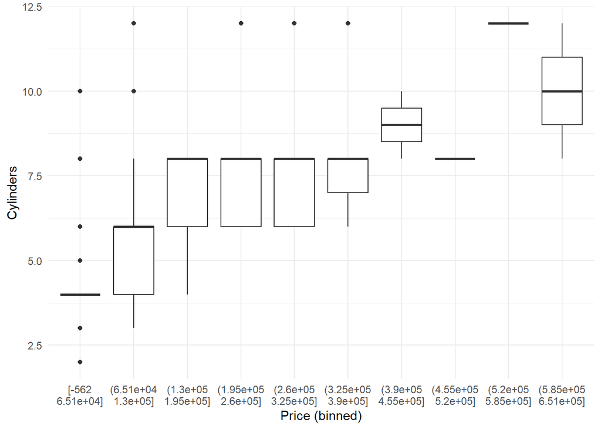

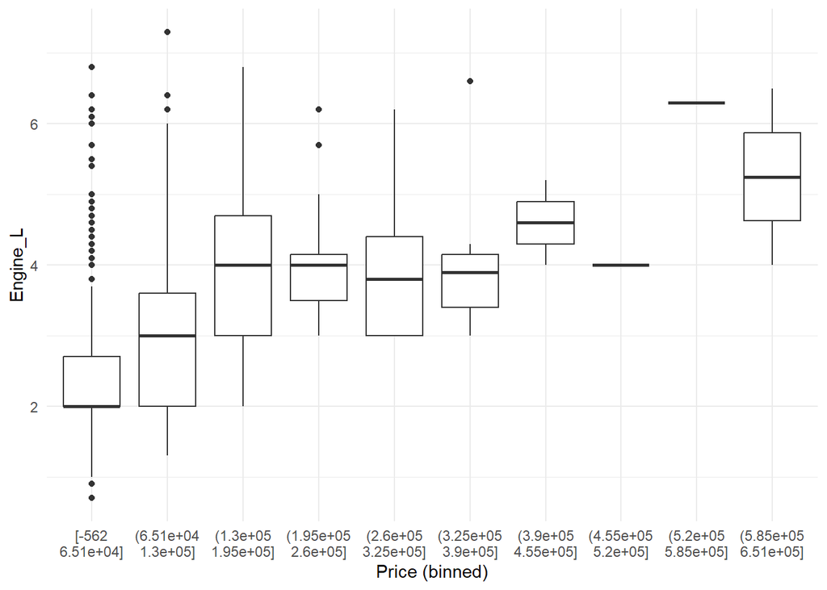

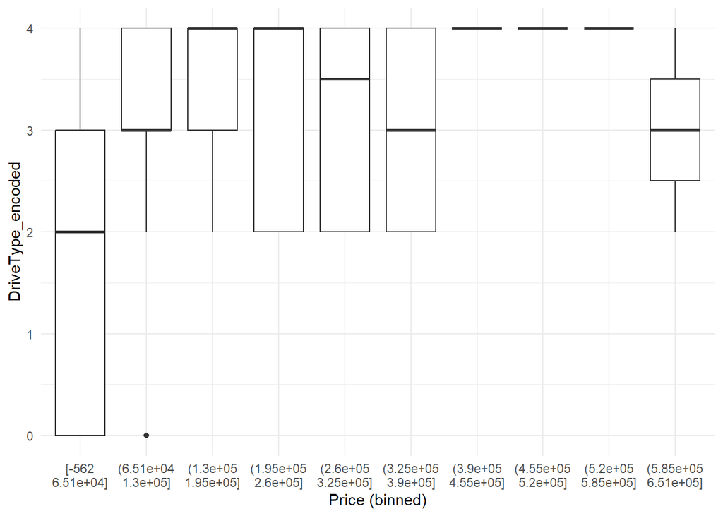

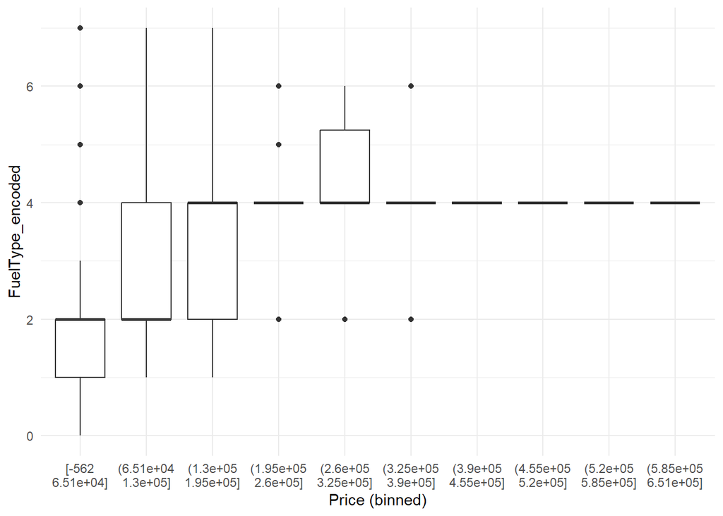

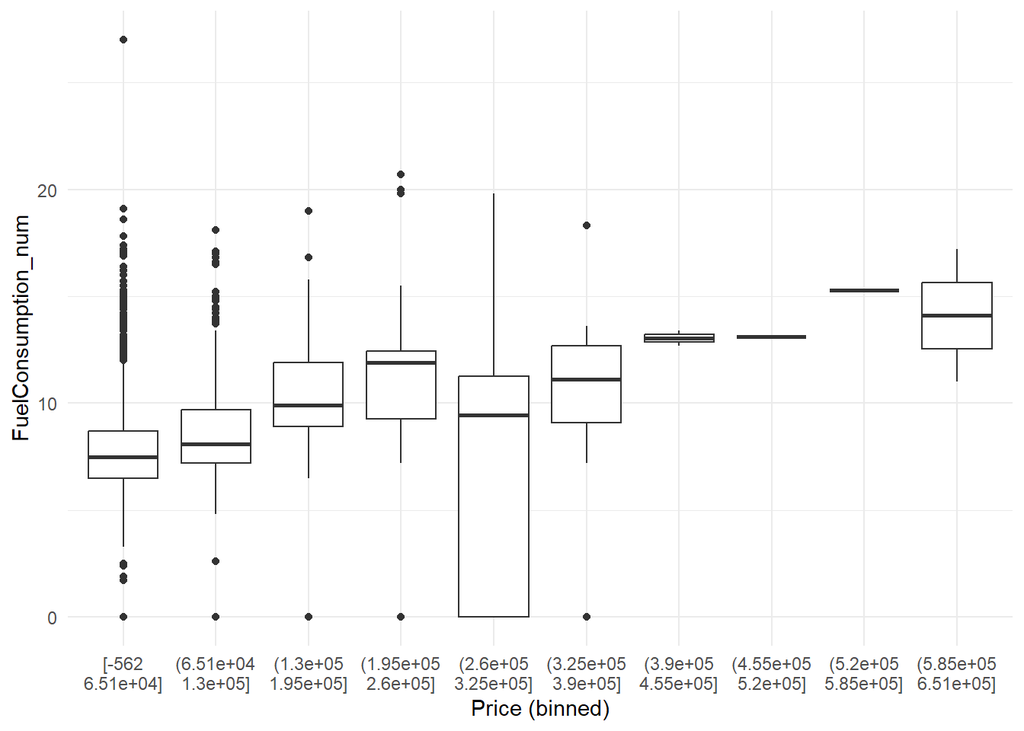

[5 more figures not shown]

```r
show.boxplot <- function(data, cols, target, bins = 5) {
  data <- data %>%
    mutate(target_binned = cut(.data[[target]], breaks = bins, include.lowest = TRUE))

  plots <- map(cols, ~ggplot(
    data,
    aes(x = target_binned, y = .data[[.x]])) +
      geom_boxplot(aes(group = target_binned)) +
      labs(x = paste0(target, " (binned)"), y = .x) +
      theme_minimal() +
      scale_x_discrete(labels = function(x) gsub(",", "\n", x))  # Wrapping long bin labels
  )

  walk(plots, print)
}

show.boxplot(data = df, cols = PREDICTORS, target = TARGET, bins = 10)
```

From the boxplots we have detected quite a notable portion of outliers. Certain actions will need to be taken.

### Target Distribution

We also need to check the distribution of the target variable to see how balanced the dataset is. We have found out that the prices are highly skewed. By applying the log scale we can deal with these extremes values. Thus, we plot two histograms comparing the original distribution against the log-scaled distribution.

[figure not shown]

```r
# Histogram with log scale
ggplot(df, aes(x = Price)) +
  geom_histogram(fill = "skyblue", color = "black", bins = 30) +
  labs(
    title = "Distribution of Vehicle Prices (Log Scale)",
    x = "Price (Log10 Scale)",
    y = "Count"
  ) +
  theme_minimal()
```

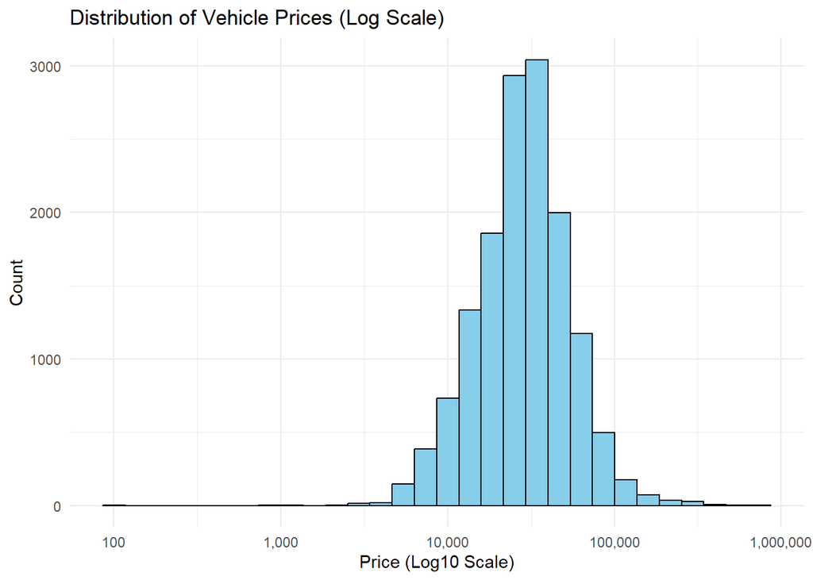

```r
# Histogram with log scale
ggplot(df, aes(x = Price)) +
  geom_histogram(fill = "skyblue", color = "black", bins = 30) +
  scale_x_log10(labels = scales::comma) +  # Log scale for skewed data
  labs(
    title = "Distribution of Vehicle Prices (Log Scale)",
    x = "Price (Log10 Scale)",
    y = "Count"
  ) +
  theme_minimal()
```

From the plots above we can tell that scaling helped making the distribution more normal.

## Saving to csv

Since we performed some preprocessing we save the data into

*/data/preprocessed/*

```r
selected_df <- df %>% select(all_of(PREDICTORS), all_of(TARGET))

write.csv(selected_df, file = "../../data/preprocessed/cars_v1.csv", row.names = FALSE)  # Avoid row numbers
```

## Conclusion

During performing EDA we have found out that: